# R Exercises - Spectroscopic data - Solution

2020-09-21

# Exercise 1

- Load the `readxl` and `tidyverse` libraries.

```r
library(readxl)
library(tidyverse)
```

- Load `FTIR_rocks.xlsx` into a `data.frame` (in fact, `tibble`).

```r
# Place the Rmd file you are working on in the same folder as the one containing the "Data" folder
# If you do so, the path is relative to where your working Rmd file is located :
df <- read_excel("Data/FTIR_rocks.xlsx")
# Otherwise, you need to provide the whole absolute path
df <- read_excel("/Users/colin/Downloads/Data/FTIR_rocks.xlsx")
```

- Rename the columns with simpler names, such as “w”, “r1”, “r2” and “r3”

```r
names(df) <- c("w","r1","r2","r3")
```

- Find the wavenumber value of the maximum of each spectrum

```r
max1 <- df$w[which.max(df$r1)]
max2 <- df$w[which.max(df$r2)]
max3 <- df$w[which.max(df$r3)]
max1;max2;max3
```

```
## [1] 2924.912
```

```
## [1] 1594.092
```

```
## [1] 2925.876
```

- Create a function `norm01()` that, given a vector, returns the vector normalized to [0,1]

```r
norm01 <- function(x){
    (x-min(x))/(max(x)-min(x))
}
# check it's working
x <- 1:10
norm01(x)
```

```
##  [1] 0.0000000 0.1111111 0.2222222 0.3333333 0.4444444 0.5555556 0.6666667
##  [8] 0.7777778 0.8888889 1.0000000
```

- Normalize all columns of FTIR intensity to [0,1]

```r
# First, let's make the tibble tidy
df_tidy <- df %>% pivot_longer(cols=-w,
                    names_to="rock",
                    values_to="intensity")
df_tidy
```

```
## # A tibble: 14,154 x 3
##        w rock  intensity
##    <dbl> <chr>     <dbl>
##  1 5199. r1      0.00566
##  2 5199. r2      0.00225
##  3 5199. r3      0.0346
##  4 5198. r1      0.00568
##  5 5198. r2      0.00191
##  6 5198. r3      0.0346
##  7 5197. r1      0.00570
##  8 5197. r2      0.00186
##  9 5197. r3      0.0346
## 10 5196. r1      0.00581
## # … with 14,144 more rows
```

```r
# now add the new column 'intensity_n' containing the normalized intensities
df_tidy <- df_tidy %>%
    group_by(rock) %>%
    mutate(intensity_n = norm01(intensity))
df_tidy
```

```
## # A tibble: 14,154 x 4
## # Groups:   rock [3]
##        w rock  intensity intensity_n
##    <dbl> <chr>     <dbl>       <dbl>
##  1 5199. r1      0.00566     0.00687
##  2 5199. r2      0.00225     0.00517
##  3 5199. r3      0.0346      0.0385
##  4 5198. r1      0.00568     0.00689
##  5 5198. r2      0.00191     0.00437
##  6 5198. r3      0.0346      0.0385
##  7 5197. r1      0.00570     0.00691
##  8 5197. r2      0.00186     0.00427
##  9 5197. r3      0.0346      0.0385
## 10 5196. r1      0.00581     0.00705
## # … with 14,144 more rows
```

- Using base graphics or `ggplot2`, as you wish, try to reproduce the following graphs:

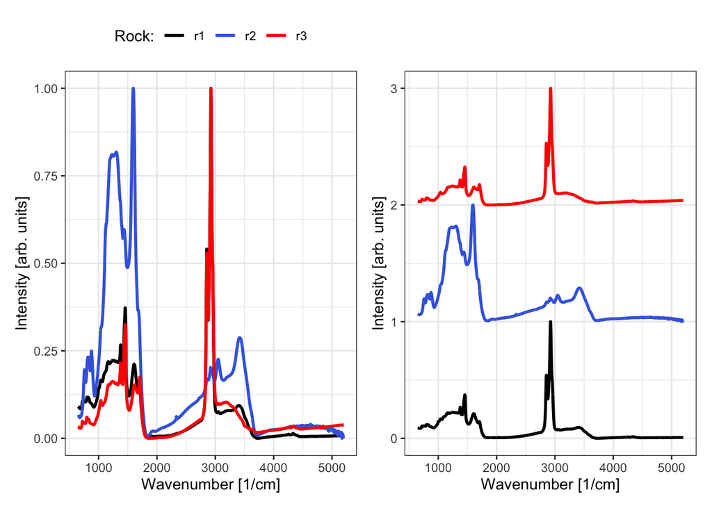

```r
P1 <- df_tidy %>%
    ggplot(aes(x=w, y=intensity_n, color=rock)) +
        # add the lines with thickness of 1
        geom_line(size=1) +
        # change the axis labels
        labs(x="Wavenumber [1/cm]", y="Intensity [arb. units]") +
        theme_bw() +
        # set the color to the wanted colors and give a name to
        # the legend if you want to plot the legend
        # if this line is absent, ggplot uses its default colors (blue, red, green)
        scale_color_manual(values = c("black", "royalblue", "red"), name="Rock:") +
        # to remove the legend, set it to "none"
        # if you remove this line, the default is to show the legend on the right
        theme(legend.position = "top")
P2 <- df_tidy %>%
    ggplot(aes(x=w,
               y=intensity_n + as.numeric(factor(rock)) - 1,
               color=rock)) +
        geom_line(size=1)+
        labs(x="Wavenumber [1/cm]", y="Intensity [arb. units]")+
        theme_bw()+
        theme(legend.position = "none")+
        scale_color_manual(values = c("black", "royalblue", "red"))
library(patchwork)
P1+P2
```

# Exercise 2

- Find in the folder “Data” the list of files with the pattern “rubis_” in their name (check out the `list.files()` function) and store it in `flist`

```r
flist <- list.files(path="Data", pattern = "rubis_")
```

- What is the length of `flist`?

```r
length(flist)
```

```
## [1] 17
```

- Initialize two empty tibbles called `spec` (storing all spectra) and `maxpos` (storing the position of the maximum for each spectrum)

```r
spec   <- tibble()
maxpos <- tibble(name=flist, max=NA)
```

- Using a `for` loop, load each file in `flist` and store them into `spec` by *making it tidy*, and store the position of the maximum of each spectrum in `maxpos`

```r
for(file in flist){
    d <- read_table2(file.path("Data",file), col_names = c("w","int"))
    d$name <- file
    maxpos$max[file==flist] <- d$w[which.max(d$int)]
    spec <- bind_rows(spec,d)
}
spec
```

```
## # A tibble: 17,255 x 3
##        w   int name
##    <dbl> <dbl> <chr>
##  1 3064.  43.9 rubis_01.txt
##  2 3064.  47.9 rubis_01.txt
##  3 3064.  44.5 rubis_01.txt
##  4 3065.  50.5 rubis_01.txt
##  5 3065.  50.5 rubis_01.txt
##  6 3065.  44.5 rubis_01.txt
##  7 3065.  44.9 rubis_01.txt
##  8 3066.  39.9 rubis_01.txt
##  9 3066.  49.5 rubis_01.txt
## 10 3066.  48.9 rubis_01.txt
## # … with 17,245 more rows
```

```r
maxpos
```

```
## # A tibble: 17 x 2
##    name           max
##    <chr>        <dbl>
##  1 rubis_01.txt 3202.
##  2 rubis_02.txt 3211.
##  3 rubis_03.txt 3219.
##  4 rubis_04.txt 3226.
##  5 rubis_05.txt 3234.
##  6 rubis_06.txt 3241.
##  7 rubis_07.txt 3249.
##  8 rubis_08.txt 3256.
##  9 rubis_10.txt 3270.
## 10 rubis_12.txt 3285.
## 11 rubis_14.txt 3300.
## 12 rubis_17.txt 3321.
## 13 rubis_21.txt 3348.
## 14 rubis_23.txt 3360.
## 15 rubis_25.txt 3372.
## 16 rubis_27.txt 3385.
## 17 rubis_29.txt 3400.
```

Another version of this that does not use a for loop would be like so (try to understand what’s happening in this code by running each line one after the other and looking at the help on the functions used):

```r
spec <- tibble(name=flist) %>%
    mutate(data=map(name, ~read_table2(file.path("Data",.),
                                       col_names = c("w","int")))
          ) %>%
    unnest(data)
maxpos <- spec %>%
    group_by(name) %>%
    summarise(max = w[which.max(int)])
```

- Plot the first spectrum in `spec` to see the x range

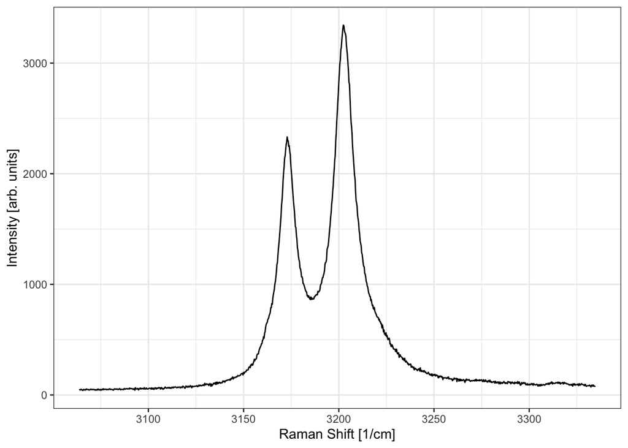

```r
spec %>%
    filter(name==flist[1]) %>%
    ggplot(aes(x=w, y=int))+
        geom_line()+
        labs(x="Raman Shift [1/cm]", y="Intensity [arb. units]")+
        theme_bw()
```

- Using `ggplot2`, plot the spectra normalized to [0,1] and stacked on top of each other with a vertical shift of 1

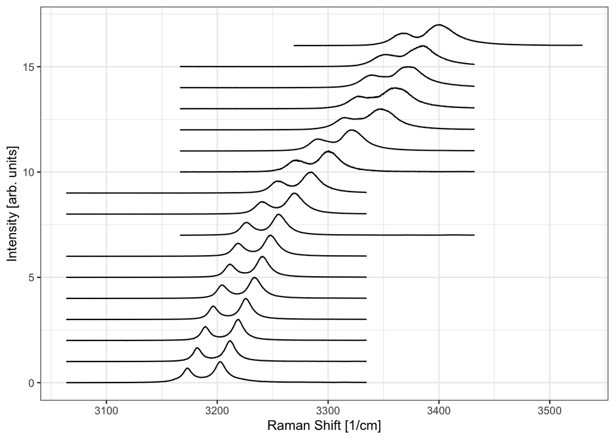

```r
spec %>%
    group_by(name) %>%
    mutate(int_n = norm01(int)) %>%
    ggplot(aes(x=w,
               y=int_n + as.numeric(factor(name)) - 1,
               group=name))+
        geom_line()+
        labs(x="Raman Shift [1/cm]", y="Intensity [arb. units]")+
        theme_bw()
```

- Plot the evolution of the position of the maximum (expected graph below)

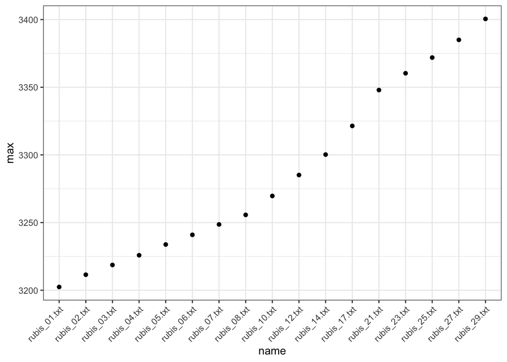

```r
maxpos %>%
    ggplot(aes(x=name, y=max))+
        geom_point()+
        theme_bw()+
        theme(axis.text.x = element_text(angle = 45, hjust=1))
```